# How Katie Ledecky Stacks Up Against Male Swimmers

Data and [R](https://www.r-project.org/) code for the analysis supporting [this August 22, 2016 BuzzFeed News article](https://www.buzzfeed.com/peteraldhous/katie-ledecky-superhuman) on the gender gap in swimming and track-and-field athletics.

Inspired by the Katie Ledecky’s performances at the 2016 Olympics in Rio de Janeiro, and the [comment](http://www.usaswimming.org/ViewNewsArticle.aspx?TabId=0&itemid=13563&mid=14491) from a male teammate that he’d seen her “break a lot of guys in practice,” this analysis examined the sporting gender gap by looking at gold medal performances over Olympic history and contemporary world records.

Gender gaps are given as percentages by which the best woman’s performance lags behind the best man’s.

The calculated gender gaps all scale between between 0% and a theoretical maximum of 100%.

The analysis considers only events where performances are directly comparable for men and women – so events like throws (where the men’s projectiles are heavier), are excluded. The historical Olympics analysis considers modern events only.

## Data

#### Olympic history

Data from the [International Olympic Committee](https://www.olympic.org/).

- `olympic_athletics_men.csv`
- `olympic_athletics_women.csv`
- `olympic_swimming_men.csv`
- `olympic_swimming_women.csv`

#### Contemporary world records

World records on August 22, 2016; data from [FINA](http://www.fina.org), the international swimming association, the [International Association of Athletics Federations](https://www.iaaf.org/), and the [International Olympic Committee](https://www.rio2016.com/en/records) for records set during the Rio Games.

- `wr_swimming_men.csv`
- `wr_swimming_women.csv`
- `wr_track_men.csv`
- `wr_track_women.csv`
- `wr_field_men.csv`
- `wr_field_women.csv`

The following fields are used to calculate gender gaps:

- `Time_S` Time in seconds, for a race.
- `Distance` Distance in meters, for a race.
- `Mark` Distance or height in meters, for jumps.

### Olympic history

#### Data preparation

```r
# load required packages
library(dplyr)
library(readr)

# import data
olympic_swimming_women <- read_csv("data/olympic_swimming_women.csv")
olympic_swimming_men <- read_csv("data/olympic_swimming_men.csv")
olympic_athletics_women <- read_csv("data/olympic_athletics_women.csv")
olympic_athletics_men <- read_csv("data/olympic_athletics_men.csv")

# join women's to men's swimming data, calculate gender gap
olympic_swimming_gap <- full_join(olympic_swimming_women, olympic_swimming_men, by=c("Event","Year")) %>%
  mutate(Speed.x=Distance.x/Time_S.x,
         Speed.y=Distance.y/Time_S.y,
         Gap=100-(Speed.x/Speed.y*100))

# join women's to men's athletics data
olympic_athletics_gap <- full_join(olympic_athletics_women, olympic_athletics_men, by=c("Event","Year"))

# separate into track and field, calculate gender gaps
olympic_track_gap <- olympic_athletics_gap %>%
  filter(!is.na(Distance.x)) %>%
  mutate(Speed.x=Distance.x/Time_S.x,
         Speed.y=Distance.y/Time_S.y,
         Gap=100-(Speed.x/Speed.y*100))

olympic_field_gap <- olympic_athletics_gap %>%
  filter(is.na(Distance.x)) %>%
  mutate(Gap=100-(Mark.x/Mark.y*100))

# recombine into single data frame
olympic_athletics_gap <- bind_rows(olympic_track_gap,olympic_field_gap)
```

#### Charts

The lines on the two charts that follow are drawn by [loess regression](http://www.tandfonline.com/doi/abs/10.1080/01621459.1979.10481038) using the `geom_smooth` function in the [ggplot2](http://docs.ggplot2.org/current/) package with its default `span` setting of `0.75`. The charts were manually annotated for publication.

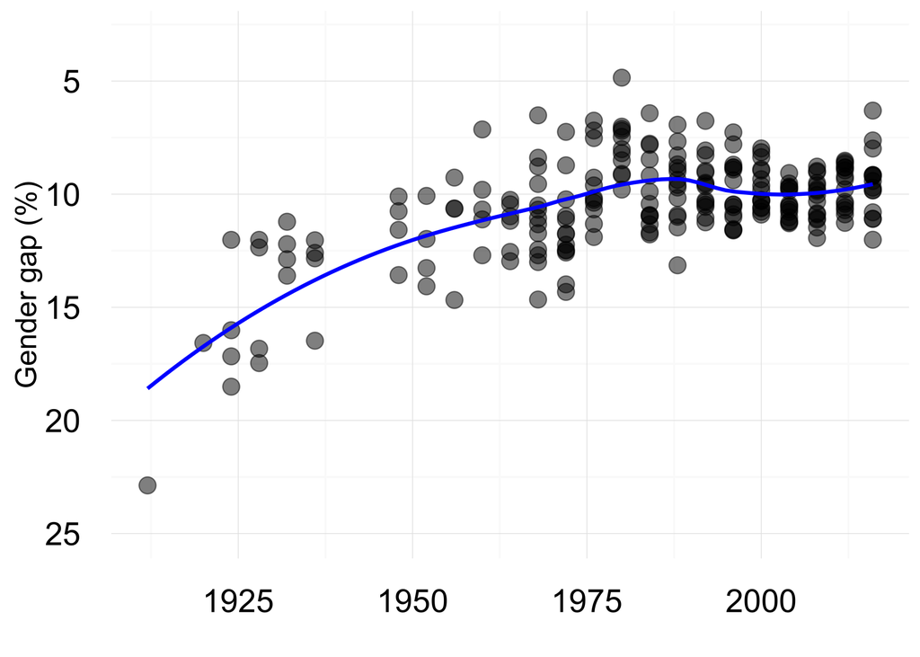

```r
# load required package
library(ggplot2)

# swimming gender gap chart
ggplot(olympic_swimming_gap, aes(x=Year, y=Gap)) +
  geom_point(size=4,alpha=0.5) +
  geom_smooth(se = FALSE, color = "blue") +
  theme_minimal() +
  theme(text=element_text(size=22)) +
  theme(axis.title = element_text(size=16)) +
  ylim(c(25,3)) +
  ylab("Gender gap (%)") +
  xlab("")
```

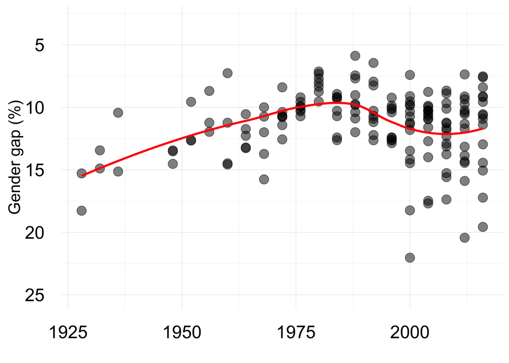

```r
# track and field gender gap chart
ggplot(olympic_athletics_gap, aes(x=Year, y=Gap)) +
  geom_point(size=4,alpha=0.5) +
  geom_smooth(se = FALSE, color = "red") +
  theme_minimal() +
  theme(text=element_text(size=22)) +
  theme(axis.title = element_text(size=16)) +
  ylim(c(25,3)) +
  ylab("Gender gap (%)") +
  xlab("")
```

### Contemporary world records

#### Data preparation

```r
# import data
wr_swimming_men <- read_csv("data/wr_swimming_men.csv")
wr_swimming_women <- read_csv("data/wr_swimming_women.csv")
wr_track_men <- read_csv("data/wr_track_men.csv")
wr_track_women <- read_csv("data/wr_track_women.csv")
wr_field_men <- read_csv("data/wr_field_men.csv")
wr_field_women <- read_csv("data/wr_field_women.csv")

# join women's to men's swimming data, calculate gender gap
wr_swimming_gap <- full_join(wr_swimming_women, wr_swimming_men, by="Event") %>%
  mutate(Speed.x=Distance.x/Time_S.x,
         Speed.y=Distance.y/Time_S.y,
         Gap=100-(Speed.x/Speed.y*100),
         Type="Swimming")

# join women's to men's track data, calculate gender gap
wr_track_gap <- full_join(wr_track_women, wr_track_men, by="Event") %>%
  mutate(Speed.x=Distance.x/Time_S.x,
         Speed.y=Distance.y/Time_S.y,
         Gap=100-(Speed.x/Speed.y*100),
         Type="Track and Field")

# join women's to men's field data, calculate gender gap
wr_field_gap <- full_join(wr_field_women, wr_field_men, by="Event") %>%
  mutate(Gap=100-(Mark.x/Mark.y*100),
         Type="Track and Field")

# combine into a single data frame
wr_combined_gap <- bind_rows(wr_swimming_gap,wr_track_gap,wr_field_gap)
```

#### Chart

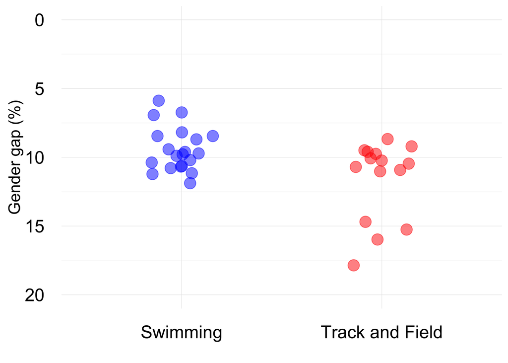

```r
ggplot(wr_combined_gap, aes(x=Type,y=Gap,color=Type)) +
  theme_minimal() +
  theme(text=element_text(size=22)) +
  theme(axis.title = element_text(size=16)) +
  geom_jitter(size=5, alpha = 0.5, width = 0.4) +
  scale_color_manual(values=c("blue","red")) +
  ylim(c(20,0)) +
  guides(color=FALSE) +
  ylab("Gender gap (%)") + xlab("")
```

For publication, this chart was edited, manually adjusting the horizontal position of points to minimize overlap, and annotated.